```python
import os
import pandas as pd
import numpy  as np
import matplotlib.pyplot as plt
from predictPy import Analisis_Predictivo
from sklearn.preprocessing import StandardScaler
from sklearn.model_selection import train_test_split
from sklearn.ensemble import RandomForestClassifier
from sklearn.metrics import confusion_matrix
from sklearn.tree import DecisionTreeClassifier
from sklearn.ensemble import AdaBoostClassifier
from sklearn.ensemble import GradientBoostingClassifier
from sklearn.utils import resample
from sklearn.neighbors import KNeighborsClassifier
```

Tarea 2

# Ejercicio 1: [30 puntos] En este ejercicio vamos a usar la tabla de datos `potabilidad_v2.csv`, que contiene diferentes métricas de calidad del agua para cuerpos de agua distintos. Para esta tabla, las 9 primeras columnas corresponden a las variables predictoras y la variable `Potability` es la variable a predecir, la cual indica si el agua es segura para el consumo humano o no.

Realice lo siguiente:

## 1. Use Bosques Aleatorios, ADABoosting y XGBoosting en **Python** para generar un modelo predictivo para la tabla `potabilidad_v2.csv` usando el 75 % de los datos para la tabla aprendizaje y un 25% para la tabla testing. Use la configuración de parámetros que usted mejor considere o identifique.

```python
datos = pd.read_csv('../datos/potabilidad_v2.csv',delimiter=',',decimal=".", index_col =0 )

print(datos.info(), "\n")
datos.head()
```

```
<class 'pandas.core.frame.DataFrame'>
Int64Index: 2011 entries, 4 to 3272
Data columns (total 10 columns):
 #   Column           Non-Null Count  Dtype
---  ------           --------------  -----
 0   ph               2011 non-null   float64
 1   Hardness         2011 non-null   float64
 2   Solids           2011 non-null   float64
 3   Chloramines      2011 non-null   float64
 4   Sulfate          2011 non-null   float64
 5   Conductivity     2011 non-null   float64
 6   Organic_carbon   2011 non-null   float64
 7   Trihalomethanes  2011 non-null   float64
 8   Turbidity        2011 non-null   float64
 9   Potability       2011 non-null   object
dtypes: float64(9), object(1)
memory usage: 172.8+ KB
None
```

|  | ph | Hardness | Solids | Chloramines | Sulfate | Conductivity | Organic_carbon | Trihalomethanes | Turbidity | Potability |
| --- | --- | --- | --- | --- | --- | --- | --- | --- | --- | --- |
| 4 | 8.316766 | 214.373394 | 22018.417441 | 8.059332 | 356.886136 | 363.266516 | 18.436524 | 100.341674 | 4.628771 | No |
| 5 | 9.092223 | 181.101509 | 17978.986339 | 6.546600 | 310.135738 | 398.410813 | 11.558279 | 31.997993 | 4.075075 | No |
| 6 | 5.584087 | 188.313324 | 28748.687739 | 7.544869 | 326.678363 | 280.467916 | 8.399735 | 54.917862 | 2.559708 | No |
| 7 | 10.223862 | 248.071735 | 28749.716544 | 7.513408 | 393.663396 | 283.651634 | 13.789695 | 84.603556 | 2.672989 | No |
| 8 | 8.635849 | 203.361523 | 13672.091764 | 4.563009 | 303.309771 | 474.607645 | 12.363817 | 62.798309 | 4.401425 | No |

### Bosques Aleatorios

```python
instancia_bosques = RandomForestClassifier(n_estimators = 5, criterion = "gini", min_samples_split = 27,random_state=0)


analisis_bosques = Analisis_Predictivo(datos,predecir= "Potability",modelo=instancia_bosques,estandarizar= True,
                                       train_size= 0.75, random_state=0)

resultados_bosques = analisis_bosques.fit_predict_resultados()
```

```
Matriz de Confusión:
[[232  77]
 [117  77]]

Precisión Global:
0.614314115308151

Error Global:
0.38568588469184895

Precisión por categoría:
         No        Si
0  0.750809  0.396907
```

### ADA Boosting

```python
# Instancia Árboles de decisión
instancia_tree = DecisionTreeClassifier(min_samples_split=2, max_depth=None,
                                        criterion="gini")

instancia_ada = AdaBoostClassifier(base_estimator=instancia_tree,
                                            n_estimators=200)

analisis_ada = Analisis_Predictivo(datos,predecir= "Potability",modelo=instancia_ada,estandarizar= True,
                                       train_size= 0.75)

resultados_ada = analisis_ada.fit_predict_resultados()
```

```
Matriz de Confusión:
[[192 113]
 [ 85 113]]

Precisión Global:
0.6063618290258449

Error Global:
0.3936381709741551

Precisión por categoría:
         No        Si
0  0.629508  0.570707
```

### XGBoosting

```python
instancia_gbc = GradientBoostingClassifier(n_estimators=100,min_samples_split=2, random_state=0)

analisis_xgb = Analisis_Predictivo(datos,predecir= "Potability",modelo=instancia_gbc,train_size= 0.75, random_state = 0)


resultados_xgb = analisis_xgb.fit_predict_resultados()
```

```
Matriz de Confusión:
[[267  42]
 [129  65]]

Precisión Global:
0.6600397614314115

Error Global:
0.3399602385685885

Precisión por categoría:
         No        Si
0  0.864078  0.335052
```

## 2. Según los gráficos de importancia de variables, indique cuáles son las 4 variables más importantes para los modelos.

### Bosques Aleatorios

```
Importancia de las variables:  [0.06309903 0.07729126 0.08994259 0.09227216 0.10741969 0.1088457
 0.12781656 0.16029753 0.17301549]

['Organic_carbon' 'Turbidity' 'Conductivity' 'Trihalomethanes'
 'Chloramines' 'Solids' 'Hardness' 'ph' 'Sulfate']
```

```
<BarContainer object of 9 artists>
```

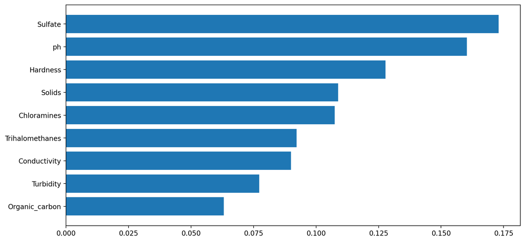

```python
#Obtenemos valores
importancia = np.array(analisis_bosques.modelo.feature_importances_)
etiquetas = np.array(analisis_bosques.predictoras)

#Ordenar
orden = np.argsort(importancia)
importancia = importancia[orden]
etiquetas = etiquetas[orden]

print("Importancia de las variables: ",importancia, "\n")
print(etiquetas)

#Gráfico
fig, ax = plt.subplots(1,1, figsize = (12,6), dpi = 200)
ax.barh(etiquetas, importancia)
```

### ADA Boosting

```
Importancia de las variables:  [0.07825475 0.07944135 0.09008833 0.09833965 0.10250382 0.10282649
 0.11608125 0.14529975 0.18716461]

['Trihalomethanes' 'Turbidity' 'Conductivity' 'Organic_carbon' 'Hardness'
 'Solids' 'Chloramines' 'Sulfate' 'ph']
```

```
<BarContainer object of 9 artists>
```

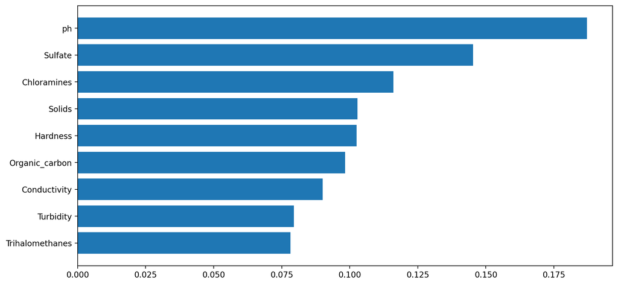

```python
#Obtenemos valores
importancia = np.array(analisis_ada.modelo.feature_importances_)
etiquetas = np.array(analisis_ada.predictoras)

#Ordenar
orden = np.argsort(importancia)
importancia = importancia[orden]
etiquetas = etiquetas[orden]

print("Importancia de las variables: ",importancia, "\n")
print(etiquetas)

#Gráfico
fig, ax = plt.subplots(1,1, figsize = (12,6), dpi = 200)
ax.barh(etiquetas, importancia)
```

### XGBoosting

```
Importancia de las variables:  [0.03730494 0.04014261 0.04562832 0.06330668 0.11553462 0.11784121
 0.1191442  0.22332529 0.23777213]

['Trihalomethanes' 'Turbidity' 'Organic_carbon' 'Conductivity' 'Hardness'
 'Solids' 'Chloramines' 'Sulfate' 'ph']
```

```
<BarContainer object of 9 artists>
```

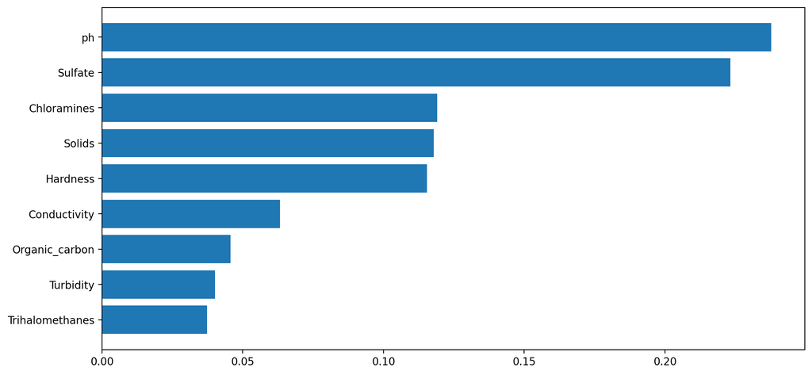

```python
#Obtenemos valores
importancia = np.array(analisis_xgb.modelo.feature_importances_)
etiquetas = np.array(analisis_xgb.predictoras)

#Ordenar
orden = np.argsort(importancia)
importancia = importancia[orden]
etiquetas = etiquetas[orden]

print("Importancia de las variables: ",importancia, "\n")
print(etiquetas)

#Gráfico
fig, ax = plt.subplots(1,1, figsize = (12,6), dpi = 200)
ax.barh(etiquetas, importancia)
```

## 3. Construya un `DataFrame` que compare los modelos construidos arriba con los mejores modelos generados en tareas anteriores para la tabla `potabilidad_v2.csv`. Para esto en cada una de las filas debe aparecer un modelo predictivo y en las columnas aparezcan los índices Precisión Global, Error Global, Precisión Positiva (PP) y Precisión Negativa (PN). ¿Cuál de los modelos es mejor para estos datos? Guarde los datos de este DataFrame, ya que se irá modificando en próximas tareas.

```python
### Bosques Aleatorios

resultados_bosques.pop("Matriz de Confusión")

categorias = resultados_bosques["Precisión por categoría"]

resultados_bosques.pop("Precisión por categoría")

categorias = categorias.rename(columns={'No': 'PN', 'Si':"PP"},index = {0:'bosques'})


Bosques = pd.concat([pd.DataFrame([resultados_bosques], index = ['bosques']), categorias], axis=1)
```

```python
### ADA Boosting

resultados_ada.pop("Matriz de Confusión")

categorias = resultados_ada["Precisión por categoría"]

resultados_ada.pop("Precisión por categoría")

categorias = categorias.rename(columns={'No': 'PN', 'Si':"PP"},index = {0:'ADA'})


ADA = pd.concat([pd.DataFrame([resultados_ada], index = ['ADA']), categorias], axis=1)
```

```python
### XG Boosting

resultados_xgb.pop("Matriz de Confusión")

categorias = resultados_xgb["Precisión por categoría"]

resultados_xgb.pop("Precisión por categoría")

categorias = categorias.rename(columns={'No': 'PN', 'Si':"PP"},index = {0:'XG Boosting'})


XG = pd.concat([pd.DataFrame([resultados_xgb], index = ['XG Boosting']), categorias], axis=1)
```

```python
indices = pd.concat([Bosques, ADA, XG], axis=0)

indices2 = pd.read_csv('tabla_comparativa1.csv',delimiter=',',decimal=".",index_col=0)

indices = pd.concat([indices, indices2], axis=0)

indices
```

[output not shown]

Aunque la precisión global del modelos de árboles binarios sea más alta continua siendo mejor KNN por predecir mejor la potabilidad.

```python
indices.to_csv('tabla_comparativa2.csv', index = True)
```

# Ejercicio 2: [40 puntos] Este conjunto de datos es originalmente del Instituto Nacional de Diabetes y Enfermedades Digestivas y Renales. El objetivo del conjunto de datos es predecir de forma diagnóstica si un paciente tiene diabetes o no, basándose en determinadas medidas de diagnóstico incluidas en el conjunto de datos.

Realice lo siguiente:

## 1. Cargue en Python la tabla de datos `diabetes.csv.`

```python
datos = pd.read_csv('../datos/diabetes_V2.csv',delimiter=',',decimal=".",index_col=0)
print(datos.info(), "\n")
print(datos.shape)

# Convierte las variables de object a categórica
datos['genero'] = datos['genero'].astype('category')

#Convertimos a Dummy algunas de las variables predictoras
datos = pd.get_dummies(datos,columns=["genero"])
```

```
<class 'pandas.core.frame.DataFrame'>
Int64Index: 390 entries, 1 to 390
Data columns (total 15 columns):
 #   Column         Non-Null Count  Dtype
---  ------         --------------  -----
 0   colesterol     390 non-null    int64
 1   glucosa        390 non-null    int64
 2   hdl_chol       390 non-null    int64
 3   prop_col_hdl   390 non-null    float64
 4   edad           390 non-null    int64
 5   genero         390 non-null    object
 6   altura         390 non-null    int64
 7   peso           390 non-null    int64
 8   IMC            390 non-null    float64
 9   ps_sistolica   390 non-null    int64
 10  ps_diastolica  390 non-null    int64
 11  cintura        390 non-null    int64
 12  caderas        390 non-null    int64
 13  prop_cin_cad   390 non-null    float64
 14  diabetes       390 non-null    object
dtypes: float64(3), int64(10), object(2)
memory usage: 48.8+ KB
None

(390, 15)
```

## 2. Use Bosques Aleatorios, ADABoosting y XGBoosting en **Python** para generar modelos predictivos para la tabla datos `diabetes.csv` usando el 75 % de los datos para la tabla aprendizaje y un 25% para la tabla testing. Use la configuración de parámetros que usted mejor considere o identifique. Luego calcule para los datos de testing la matriz de confusión, la precisión global y la precisión para cada una de las dos categorías. ¿Son buenos los resultados? Explique.

### Bosques Aleatorios

```python
instancia_bosques = RandomForestClassifier(n_estimators = 15, criterion = "gini", min_samples_split = 10,random_state=0)


analisis_bosques = Analisis_Predictivo(datos,predecir= "diabetes",modelo=instancia_bosques,estandarizar= True,
                                       train_size= 0.75, random_state=0)

resultados_bosques = analisis_bosques.fit_predict_resultados()
```

```
Matriz de Confusión:
[[12  8]
 [ 1 77]]

Precisión Global:
0.9081632653061225

Error Global:
0.09183673469387754

Precisión por categoría:
   Diabetes  No diabetes
0       0.6     0.987179
```

## ADA boosting

```python
# Instancia Árboles de decisión
instancia_tree = DecisionTreeClassifier(min_samples_split=10, max_depth=None,
                                        criterion="gini")

instancia_ada = AdaBoostClassifier(base_estimator=instancia_tree,
                                            n_estimators=50)

analisis_ada = Analisis_Predictivo(datos,predecir= "diabetes",modelo=instancia_ada,estandarizar= True,
                                       train_size= 0.75)

resultados_ada = analisis_ada.fit_predict_resultados()
```

```
Matriz de Confusión:
[[12  4]
 [ 2 80]]

Precisión Global:
0.9387755102040817

Error Global:
0.061224489795918324

Precisión por categoría:
   Diabetes  No diabetes
0      0.75      0.97561
```

### XG Boosting

```python
instancia_gbc = GradientBoostingClassifier(n_estimators=200,min_samples_split=60, random_state=0)

analisis_xgb = Analisis_Predictivo(datos,predecir= "diabetes",modelo=instancia_gbc,train_size= 0.75, random_state = 0)


resultados_xgb = analisis_xgb.fit_predict_resultados()
```

```
Matriz de Confusión:
[[11  9]
 [ 2 76]]

Precisión Global:
0.8877551020408163

Error Global:
0.11224489795918369

Precisión por categoría:
   Diabetes  No diabetes
0      0.55     0.974359
```

Los resultados son buenos para `ADA Boosting`, además de tener una precisión global alta, su diagnóstico positivo es del 75%

## 3. Repita el ítem anterior, pero esta vez seleccione 6 variables predictoras. Para esto utilice el gráfico de importancia de variables del método Bosques Aleatorios. ¿Mejora la predicción?.

```
Importancia de las variables:  [0.00000000e+00 3.15799264e-04 2.03377201e-02 2.19379156e-02
 2.51931620e-02 2.58750912e-02 2.90335135e-02 3.21452095e-02
 3.31747282e-02 3.84136443e-02 3.85143842e-02 4.93792411e-02
 5.75644077e-02 5.78888890e-02 5.70226294e-01]

['genero_female' 'genero_male' 'caderas' 'IMC' 'prop_cin_cad'
 'ps_diastolica' 'ps_sistolica' 'altura' 'cintura' 'hdl_chol' 'peso'
 'colesterol' 'prop_col_hdl' 'edad' 'glucosa']
```

```
<BarContainer object of 15 artists>
```

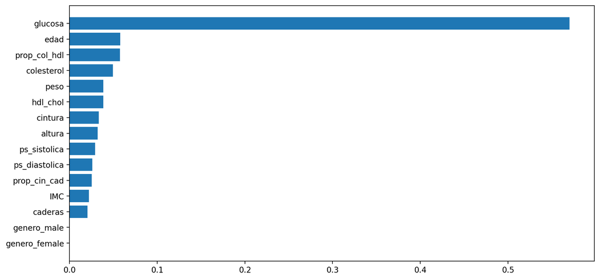

```python
#Obtenemos valores
importancia = np.array(analisis_bosques.modelo.feature_importances_)
etiquetas = np.array(analisis_bosques.predictoras)

#Ordenar
orden = np.argsort(importancia)
importancia = importancia[orden]
etiquetas = etiquetas[orden]

print("Importancia de las variables: ",importancia, "\n")
print(etiquetas)

#Gráfico
fig, ax = plt.subplots(1,1, figsize = (12,6), dpi = 200)
ax.barh(etiquetas, importancia)
```

```python
datos1 = datos[["glucosa","edad","prop_col_hdl","colesterol","peso","hdl_chol","diabetes"]]

datos1
```

|  | glucosa | edad | prop_col_hdl | colesterol | peso | hdl_chol | diabetes |
| --- | --- | --- | --- | --- | --- | --- | --- |
| 1 | 77 | 19 | 3.9 | 193 | 119 | 49 | No diabetes |
| 2 | 79 | 19 | 3.6 | 146 | 135 | 41 | No diabetes |
| 3 | 75 | 20 | 4.0 | 217 | 187 | 54 | No diabetes |
| 4 | 97 | 20 | 3.2 | 226 | 114 | 70 | No diabetes |
| 5 | 91 | 20 | 2.4 | 164 | 141 | 67 | No diabetes |
| ... | ... | ... | ... | ... | ... | ... | ... |
| 386 | 105 | 83 | 5.2 | 227 | 125 | 44 | No diabetes |
| 387 | 279 | 84 | 4.3 | 226 | 192 | 52 | Diabetes |
| 388 | 90 | 89 | 2.6 | 301 | 115 | 118 | No diabetes |
| 389 | 184 | 91 | 2.0 | 232 | 127 | 114 | Diabetes |
| 390 | 94 | 92 | 2.4 | 165 | 217 | 69 | No diabetes |

390 rows × 7 columns

```python
## Bosques Aleatorios

instancia_bosques = RandomForestClassifier(n_estimators = 15, criterion = "gini", min_samples_split = 10,random_state=0)


analisis_bosques = Analisis_Predictivo(datos1,predecir= "diabetes",modelo=instancia_bosques,estandarizar= True,
                                       train_size= 0.75, random_state=0)

resultados_bosques = analisis_bosques.fit_predict_resultados()
```

```
Matriz de Confusión:
[[ 9 11]
 [ 1 77]]

Precisión Global:
0.8775510204081632

Error Global:
0.12244897959183676

Precisión por categoría:
   Diabetes  No diabetes
0      0.45     0.987179
```

```python
## ADA Boosting


instancia_tree = DecisionTreeClassifier(min_samples_split=10, max_depth=None,
                                        criterion="gini")

instancia_ada = AdaBoostClassifier(base_estimator=instancia_tree,
                                            n_estimators=50)

analisis_ada = Analisis_Predictivo(datos1,predecir= "diabetes",modelo=instancia_ada,estandarizar= True,
                                       train_size= 0.75)

resultados_ada = analisis_ada.fit_predict_resultados()
```

```
Matriz de Confusión:
[[10  5]
 [ 0 83]]

Precisión Global:
0.9489795918367347

Error Global:
0.05102040816326525

Precisión por categoría:
   Diabetes  No diabetes
0  0.666667          1.0
```

```python
## XGBoosting

instancia_gbc = GradientBoostingClassifier(n_estimators=200,min_samples_split=60, random_state=0)

analisis_xgb = Analisis_Predictivo(datos1,predecir= "diabetes",modelo=instancia_gbc,train_size= 0.75, random_state = 0)


resultados_xgb = analisis_xgb.fit_predict_resultados()
```

```
Matriz de Confusión:
[[11  9]
 [ 4 74]]

Precisión Global:
0.8673469387755102

Error Global:
0.13265306122448983

Precisión por categoría:
   Diabetes  No diabetes
0      0.55     0.948718
```

## 4. Construya un `DataFrame` que compare los mejores modelos construidos arriba con los mejores modelos generados en tareas anteriores para la tabla diabetes.csv. Para esto en cada una de las filas debe aparecer un modelo predictivo y en las columnas aparezcan los índices Precisión Global, Error Global, Precisión Positiva (PP) y Precisión Negativa (PN). ¿Cuál de los modelos es mejor para estos datos? Guarde los datos de este DataFrame, ya que se irá modificando en próximas tareas.

```python
### Bosques Aleatorios

resultados_bosques.pop("Matriz de Confusión")

categorias = resultados_bosques["Precisión por categoría"]

resultados_bosques.pop("Precisión por categoría")

categorias = categorias.rename(columns={'No diabetes': 'PN', 'diabetes':"PP"},index = {0:'bosques'})


Bosques = pd.concat([pd.DataFrame([resultados_bosques], index = ['bosques']), categorias], axis=1)
```

```python
### ADA Boosting

resultados_ada.pop("Matriz de Confusión")

categorias = resultados_ada["Precisión por categoría"]

resultados_ada.pop("Precisión por categoría")

categorias = categorias.rename(columns={'No diabetes': 'PN', 'diabetes':"PP"},index = {0:'ADA'})


ADA = pd.concat([pd.DataFrame([resultados_ada], index = ['ADA']), categorias], axis=1)
```

```python
### XG Boosting

resultados_xgb.pop("Matriz de Confusión")

categorias = resultados_xgb["Precisión por categoría"]

resultados_xgb.pop("Precisión por categoría")

categorias = categorias.rename(columns={'No diabetes': 'PN', 'diabetes':"PP"},index = {0:'XG Boosting'})


XG = pd.concat([pd.DataFrame([resultados_xgb], index = ['XG Boosting']), categorias], axis=1)
```

```python
indices = pd.concat([Bosques, ADA, XG], axis=0)

indices2 = pd.read_csv('tabla_comparativa1.2.csv',delimiter=',',decimal=".",index_col=0)

indices = pd.concat([indices, indices2], axis=0)

indices
```

|  | Precisión Global | Error Global | Diabetes | PN |
| --- | --- | --- | --- | --- |
| bosques | 0.877551 | 0.122449 | 0.450000 | 0.987179 |
| ADA | 0.948980 | 0.051020 | 0.666667 | 1.000000 |
| XG Boosting | 0.867347 | 0.132653 | 0.550000 | 0.948718 |
| arboles | 0.887755 | 0.112245 | 0.600000 | 0.961538 |
| KNN | 0.877551 | 0.122449 | 0.650000 | 0.935897 |

El mejor modelo debido a la precisión global más alta y un mejor pronóstico de la enfermedad es `ADA Boosting`

```python
indices.to_csv('tabla_comparativa2.2.csv', index = True)
```

# Ejercicio 3: **[30 puntos]** La idea de este ejercicio es programar una Clase en Python para un nuevo método de Consenso Propio, esto basado en los métodos K-vecinos más cercanos, Árboles de Decisión, Método de Potenciación (XGBoosting) y Método de Potenciación (ADABoosting), para esto realice los siguiente:

## 1. Programe una Clase en `Python` denominada `ConsensoPropio` que tiene, además del constructor, al menos los siguientes métodos `fit(X_train, y_train, ...)` que recibe la tabla de entrenamiento y genera 4 muestras aleatorias con reemplazo (Boostraps) de los datos de aprendizaje y luego aplica en cada una de estas muestras uno de los métodos predictivos mencionados arriba. Este método debe generar un nuevo modelo predictivo que es un atributo de clase, tipo diccionario, que incluya los 4 modelos generados (todos los métodos usarán todas las variables) y las 4 de precisiones globales, respectivamente de cada modelo1, que denotamos por $(PG_1,PG_2,...,PG_4)$, donde $0 \leq PG_j \leq 1$ para $j = 1,2,...,4.$

## 2. Programe una función `predict(X_test)` que recibe la tabla de testing. Luego, para predecir aplica en cada una de las filas de la tabla de testing los 4 modelos predictivos que están almacenados dentro de la Clase en el atributo incluido para este efecto; y se establece un consenso de todos los resultados. Se debe programar una fórmula en Python que le dé mayor importancia a los métodos con mejor precisión global.

Si denotamos por $M_j(h,i)$ la probabilidad que retorna el j-ésimo modelo en el individuo i-ésimo para la categoría h de variable a predecir, donde $j$ varía de 1 hasta 4, $h$ varía desde 1 hasta $p$=número de categorías de la variable a predecir e $i$ varía de 1 hasta $s$ = cantidad de individuos en la tabla de testing, esta fórmula se define como sigue:

$$ C(i) = m, $$

donde $m$ es el valor que toma $h$ cuando se alcanza el valor máximo en la siguiente fórmula:

$$ máx_{h=1,2,...,p} \Big\{ \sum_{j=1}^{4} p_jM_j(h,i)\Big\}; $$

y $p_k = \dfrac{PG_k}{\sum_{j=1}^{4} PG_j}$ para $k=1,2,3,4$ note que $\sum_{j=1}^{4} p_j = 1$, pues son pesos.

La función `predict(X_test)` debe retornar un vector con las predicciones para todas las filas de la tabla de testing usando la función $C(i)$.

```python
class consensoPropio:
    def __init__(self,datos,porcentajentrenamiento):
        self.__datos = datos
        self.__porcentajentrenamiento = porcentajentrenamiento

    @property
    def datos(self):
        return self.__datos
    @datos.setter
    def datos(self, datos):
        self.__datos = datos

    @property
    def porcentajentrenamiento(self):
        return self.__porcentajentrenamiento
    @porcentajentrenamiento.setter
    def porcentaje_entrenamiento(self, porcentajentrenamiento):
        self.__porcentajentrenamiento = porcentajentrenamiento

    @property
    def train(self):
        return self.__train
    @train.setter
    def train(self, train):
        self.__train = train

    @property
    def test(self):
        return self.__test
    @test.setter
    def test(self, test):
        self.__test = test

    @property
    def sample_size(self):
        return self.__sample_size
    @sample_size.setter
    def sample_size(self, sample_size):
        self.__sample_size = sample_size

    @property
    def modelos(self):
        return self.__modelos
    @modelos.setter
    def modelos(self, modelos):
        self.__modelos = modelos

    @property
    def precisiones(self):
        return self.__precisiones
    @precisiones.setter
    def precisiones(self, precisiones):
        self.__precisiones = precisiones

    def split(self):
        self.train,self.test = train_test_split(self.datos,train_size=self.porcentajentrenamiento, random_state=0)
        self.sample_size = 3000

    def fit(self):
        precisionesglobales = []
        modelo = []
        modelos = []

        ## KNN
        boot = resample(self.train, replace=True, n_samples=self.sample_size, random_state=1)
        columns = boot.shape[1]
        X_aux = boot.iloc[:,0:(columns-1)]
        y_aux = boot.iloc[:,(columns-1):columns]
        X_train, X_test, y_train, y_test = train_test_split(X_aux, y_aux, train_size=self.porcentajentrenamiento, random_state=0)
        instancia_knn = KNeighborsClassifier(n_neighbors=3)
        instancia_knn.fit(X_train,y_train.iloc[:,0].values)
        modelo.append(instancia_knn)
        prediccion = instancia_knn.predict(X_test)
        matriz = confusion_matrix(y_test, prediccion)
        precisionglobal = (matriz[0][0]+matriz[1][1])/(matriz[0][0]+matriz[0][1]+matriz[1][0]+matriz[1][1])
        precisionesglobales.append(round(precisionglobal, 4))


        ## DECISIONTREE
        boot = resample(self.train, replace=True, n_samples=self.sample_size, random_state=1)
        columns = boot.shape[1]
        X_aux = boot.iloc[:,0:(columns-1)]
        y_aux = boot.iloc[:,(columns-1):columns]
        X_train, X_test, y_train, y_test = train_test_split(X_aux, y_aux, train_size=self.porcentajentrenamiento, random_state=0)
        instancia_arbol = DecisionTreeClassifier(random_state=0)
        instancia_arbol.fit(X_train,y_train)
        modelo.append(instancia_arbol)
        prediccion = instancia_arbol.predict(X_test)
        matriz = confusion_matrix(y_test, prediccion)
        precisionglobal = (matriz[0][0]+matriz[1][1])/(matriz[0][0]+matriz[0][1]+matriz[1][0]+matriz[1][1])
        precisionesglobales.append(round(precisionglobal, 4))


        ## ADA BOOSTING
        boot = resample(self.train, replace=True, n_samples=self.sample_size, random_state=1)
        columns = boot.shape[1]
        X_aux = boot.iloc[:,0:(columns-1)]
        y_aux = boot.iloc[:,(columns-1):columns]
        X_train, X_test, y_train, y_test = train_test_split(X_aux, y_aux, train_size=self.porcentajentrenamiento, random_state=0)
        instancia_potenciacion = AdaBoostClassifier(n_estimators=10, random_state=0)
        instancia_potenciacion.fit(X_train,y_train.iloc[:,0].values)
        modelo.append(instancia_potenciacion)
        prediccion = instancia_potenciacion.predict(X_test)
        matriz = confusion_matrix(y_test, prediccion)
        precisionglobal = (matriz[0][0]+matriz[1][1])/(matriz[0][0]+matriz[0][1]+matriz[1][0]+matriz[1][1])
        precisionesglobales.append(round(precisionglobal, 4))


        ##XG BOOSTING
        boot = resample(self.train, replace=True, n_samples=self.sample_size, random_state=1)
        columns = boot.shape[1]
        X_aux = boot.iloc[:,0:(columns-1)]
        y_aux = boot.iloc[:,(columns-1):columns]
        X_train, X_test, y_train, y_test = train_test_split(X_aux, y_aux, train_size=self.porcentajentrenamiento, random_state=0)
        instancia_potenciacion = GradientBoostingClassifier(n_estimators=10, random_state=0)
        instancia_potenciacion.fit(X_train,y_train.iloc[:,0].values)
        modelo.append(instancia_potenciacion)
        prediccion = instancia_potenciacion.predict(X_test)
        matriz = confusion_matrix(y_test, prediccion)
        precisionglobal = (matriz[0][0]+matriz[1][1])/(matriz[0][0]+matriz[0][1]+matriz[1][0]+matriz[1][1])
        precisionesglobales.append(round(precisionglobal, 4))

        modelos.append(modelo)
        modelos.append(precisionesglobales)
        self.modelos = modelos


    def predict(self,vector):
        columns = self.test.shape[1]
        X_aux = self.test.iloc[:,0:(columns-1)]
        y_aux = self.test.iloc[:,(columns-1):columns]
        knn = self.modelos[0][0]
        prediccion_knn = knn.predict_proba(X_aux)
        print("KNN")
        print(prediccion_knn)
        randomtree = self.modelos[0][1]
        prediccion_randomtree = randomtree.predict_proba(X_aux)
        print("Random Tree")
        print(prediccion_randomtree)
        ada = self.modelos[0][2]
        prediccion_ada = ada.predict_proba(X_aux)
        print("ADA Boosting")
        print(prediccion_ada)
        xg = self.modelos[0][3]
        prediccion_xg = xg.predict_proba(X_aux)
        print("XG Boosting")
        print(prediccion_xg)
         ## Se multiplica la probabilidad contra la precisión global para darle mayor peso a los modelos con mejor precisión global
        prediccion_knn =  self.modelos[1][0] * prediccion_knn
        prediccion_randomtree = self.modelos[1][1] * prediccion_randomtree
        prediccion_ada = self.modelos[1][2] * prediccion_ada
        prediccion_xg = self.modelos[1][3] * prediccion_xg
        matriz = []
        # Se suman las 4 probabilidades y se divide entre 4 para obtener la probabilidad ponderada
        for i in range(prediccion_knn.shape[0]):
            fila = []
            for j in range(prediccion_knn.shape[1]):
                prediccion = (prediccion_knn[i][j]+prediccion_randomtree[i][j]+prediccion_randomtree[i][j]+prediccion_ada[i][j])/4
                fila.append(prediccion)
            matriz.append(fila)
        # El valor que tenga más probabilidades es el que se devolverá
        predicciones = []
        for i in range(prediccion_knn.shape[0]):
            indice = matriz[i].index(max(matriz[i]))
            predicciones.append(vector[indice])
        self.prediccion = predicciones

    def precisiones(self):
        columns = self.test.shape[1]
        y_aux = self.test.iloc[:,(columns-1):columns]
        MC = confusion_matrix(y_aux,self.prediccion )
        nombres = list(np.unique(y_aux))
        precision_global = np.sum(MC.diagonal()) / np.sum(MC)
        error_global = 1 - precision_global
        precision_categoria  = pd.DataFrame(MC.diagonal()/np.sum(MC,axis = 1)).T
        if nombres!=None:
            precision_categoria.columns = nombres
            indices = {"Matriz de Confusión":MC,
            "Precisión Global":precision_global,
            "Error Global":error_global,
            "Precisión por categoría":precision_categoria}
        for k in indices:
            print("\n%s:\n%s"%(k,str(indices[k])))
```

## 3. Usando la tabla de datos datos `potabilidad_v2.csv` genere al azar una tabla de testing con un 20 % de los datos y con el resto de los datos construya una tabla de aprendizaje.

```python
datos = pd.read_csv('../datos/potabilidad_v2.csv',delimiter=',',decimal=".", index_col =0 )

datos.head()
```

|  | ph | Hardness | Solids | Chloramines | Sulfate | Conductivity | Organic_carbon | Trihalomethanes | Turbidity | Potability |
| --- | --- | --- | --- | --- | --- | --- | --- | --- | --- | --- |
| 4 | 8.316766 | 214.373394 | 22018.417441 | 8.059332 | 356.886136 | 363.266516 | 18.436524 | 100.341674 | 4.628771 | No |
| 5 | 9.092223 | 181.101509 | 17978.986339 | 6.546600 | 310.135738 | 398.410813 | 11.558279 | 31.997993 | 4.075075 | No |
| 6 | 5.584087 | 188.313324 | 28748.687739 | 7.544869 | 326.678363 | 280.467916 | 8.399735 | 54.917862 | 2.559708 | No |
| 7 | 10.223862 | 248.071735 | 28749.716544 | 7.513408 | 393.663396 | 283.651634 | 13.789695 | 84.603556 | 2.672989 | No |
| 8 | 8.635849 | 203.361523 | 13672.091764 | 4.563009 | 303.309771 | 474.607645 | 12.363817 | 62.798309 | 4.401425 | No |

```python
modelo = consensoPropio(datos,0.80)
modelo.split()
modelo.train
```

|  | ph | Hardness | Solids | Chloramines | Sulfate | Conductivity | Organic_carbon | Trihalomethanes | Turbidity | Potability |
| --- | --- | --- | --- | --- | --- | --- | --- | --- | --- | --- |
| 1595 | 8.733525 | 203.396130 | 24578.421221 | 6.594145 | 288.678463 | 336.824656 | 16.701920 | 68.793062 | 3.149202 | Si |
| 846 | 6.592443 | 242.480473 | 9381.239931 | 7.303184 | 312.814395 | 440.601135 | 14.027297 | 70.929879 | 3.060827 | No |
| 3212 | 6.817608 | 219.337429 | 27548.614177 | 6.298121 | 340.937614 | 530.710026 | 19.486791 | 68.568791 | 3.048292 | Si |
| 573 | 8.805178 | 157.231982 | 4728.650671 | 8.848262 | 356.773638 | 299.279775 | 9.439925 | 61.640597 | 5.176205 | No |
| 2966 | 9.459931 | 222.894659 | 14450.175747 | 6.790914 | 293.746321 | 433.145005 | 9.069161 | 67.906813 | 3.322890 | No |
| ... | ... | ... | ... | ... | ... | ... | ... | ... | ... | ... |
| 1355 | 6.453065 | 178.998245 | 23129.460178 | 6.354508 | 326.853185 | 371.882763 | 13.178301 | 41.525863 | 3.440859 | No |
| 1980 | 7.201702 | 147.711086 | 37308.994159 | 5.677451 | 279.164446 | 395.976824 | 13.326125 | 63.626894 | 3.883250 | Si |
| 2701 | 7.117579 | 186.199680 | 31528.948690 | 6.387037 | 335.348881 | 380.578265 | 19.073996 | 75.903072 | 4.333402 | No |
| 909 | 10.282068 | 198.546363 | 8108.297322 | 5.548407 | 332.017935 | 568.078980 | 15.661692 | 28.770619 | 4.572923 | No |
| 1100 | 7.269652 | 155.157520 | 31161.368388 | 3.181183 | 244.795198 | 506.010135 | 17.385515 | 73.115053 | 3.789237 | Si |

1608 rows × 10 columns

## 4. Genere modelos predictivos usando la Clase `ConsensoPropio` y el método `fit` de la clase `RandomForestClassifier` (con solamente 4 árboles, es decir, 4 boostraps), luego para la tabla de testing calcule, para ambos métodos, calcule la precisión global, el error global y la precisión por clases. ¿Cuál método es mejor?

### Consenso Propio

```python
modelo.fit()
```

```python
modelo.predict(["Si","No"])
modelo.precisiones()
```

[output not shown]

[output cut: 1575 more lines]

```
 [0.65992989 0.34007011]]

Matriz de Confusión:
[[ 86 166]
 [ 75  76]]

Precisión Global:
0.40198511166253104

Error Global:
0.598014888337469

Precisión por categoría:
        No        Si
0  0.34127  0.503311
```

### Bosques Aleatorios

```python
# Preparamos datos
X_train = modelo.train.iloc[:,0:9]
X_test = modelo.test.iloc[:,0:9]
y_train = modelo.train.iloc[:,9].ravel()
y_test = modelo.test.iloc[:,9].ravel()
```

```python
def indices_general(MC, nombres = None):
    precision_global = np.sum(MC.diagonal()) / np.sum(MC)
    error_global = 1 - precision_global
    precision_categoria  = pd.DataFrame(MC.diagonal()/np.sum(MC,axis = 1)).T
    if nombres!=None:
        precision_categoria.columns = nombres
    return {"Matriz de Confusión":MC,
            "Precisión Global":precision_global,
            "Error Global":error_global,
            "Precisión por categoría":precision_categoria}
```

```python
instancia_bosques = RandomForestClassifier(n_estimators = 4, criterion = "gini", min_samples_split = 27,random_state=0)
instancia_bosques.fit(X_train.values,y_train)
prediccion = instancia_bosques.predict(X_test.values)

labels = ["Si","No"]
MC = confusion_matrix(y_test, prediccion, labels = labels)

indices = indices_general(MC,labels)
for k in indices:
    print("\n%s:\n%s"%(k,str(indices[k])))
```

```
Matriz de Confusión:
[[ 68  83]
 [ 63 189]]

Precisión Global:
0.6377171215880894

Error Global:
0.36228287841191065

Precisión por categoría:
         Si    No
0  0.450331  0.75
```

El método `RandomForest` es mucho mejor en Precisión Global, sin embargo el método `ConsensoPropio` predijo mejor la categoría "Si" por un 5%